# Birthday Problem

T. Manke

25 Feb 2016

# The Problem:

Given $n$ people at a birthday party, how likely is it that at least two of them share a birthday?

# Sampling Excerices

Sample uniformly (with replacement) from 365 days (no Feb 29)

```r
n=40
bds=sample(1:365, n, replace=TRUE)
```

Are there any duplicated entries?

```r
dups=duplicated(bds)
```

What sort of object is dups?

```r
str(dups)
```

```
##  logi [1:40] FALSE FALSE FALSE FALSE FALSE FALSE ...
```

```r
typeof(dups)
```

```
## [1] "logical"
```

```r
summary(dups)
```

```
##    Mode   FALSE    TRUE    NA's
## logical      36       4       0
```

```r
sort(bds)
```

```
##  [1]   8  10  16  37  41  49  77  79  79  80  99 109 114 123 125 134 144
## [18] 149 157 180 195 204 206 271 275 281 281 283 300 309 309 316 319 326
## [35] 340 344 345 361 362 362
```

```r
bds[dups]
```

```
## [1]  79 281 309 362
```

```r
sum(dups,na.rm=TRUE)
```

```
## [1] 4
```

```r
any(dups)
```

```
## [1] TRUE
```

```r
anyDuplicated(bds)
```

```
## [1] 13
```

# Simulation in R

With those ingedients, determine the expected fraction of $m=1000$ parties with one or more duplicated birthdays.

```r
m=1000
bds=sample(365, n*m, replace=TRUE)
A=matrix(bds,m,n,byrow=TRUE)
x=apply(A,1,anyDuplicated)
fract=sum(x>0)/m
fract
```

```
## [1] 0.88
```

Now plot the fraction against the size of the party $n \in [1,50]$

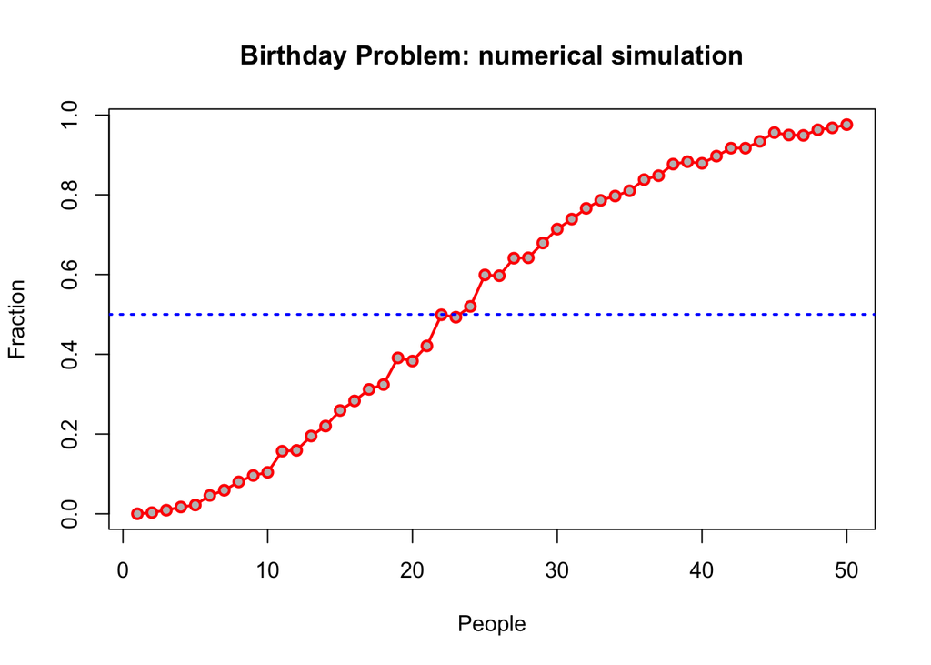

```r
fract=vector("numeric",50)
for (n in 1:50) {
  A=matrix(sample(365,n*m,replace=TRUE), m,n,byrow=TRUE)
  fract[n]=sum(apply(A,1,anyDuplicated)>0)/m
}
plot(1:50, fract, main="Birthday Problem: numerical simulation", xlab="People", ylab="Fraction",
     type="o", col="red", pch=21, bg="grey",lwd=2)
#?plot
abline(h=0.5, lty=3, col="blue", lwd=2)
```

With $n>23$ people we expect more than half of all parties to have matching birthdays.

# Analytical treatment

For any given pair of people the probability of success (sharing a birthday) is small $p=1/365 \approx 0.0027$, but in the party setting there are many such comparisons $N=n(n-1)/2 \propto n^2$. The total number of successes can be modelled by the **binomial distribution** with success probability $p$ and $N$ number of trials. Rather than simulating the process (above), we now draw $m$ random numbers from a binomial distribution

```r
m=100
n=24
p=1/365
x=rbinom(m,size=n*(n-1)/2, prob=p)
head(x)
```

```
## [1] 1 0 0 2 0 1
```

```r
table(x)
```

```
## x
##  0  1  2  3
## 49 37 12  2
```

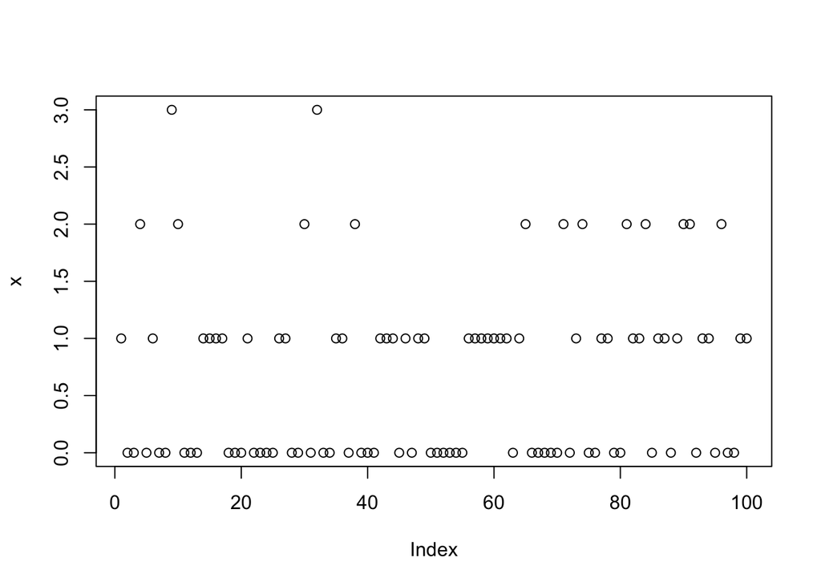

```r
plot(x)
```

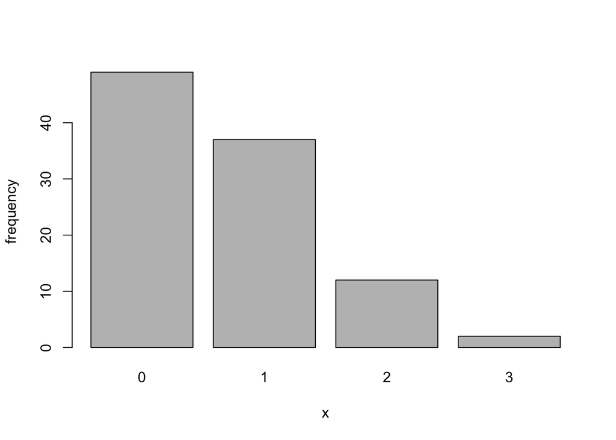

```r
barplot(table(x), xlab="x", ylab="frequency")
```

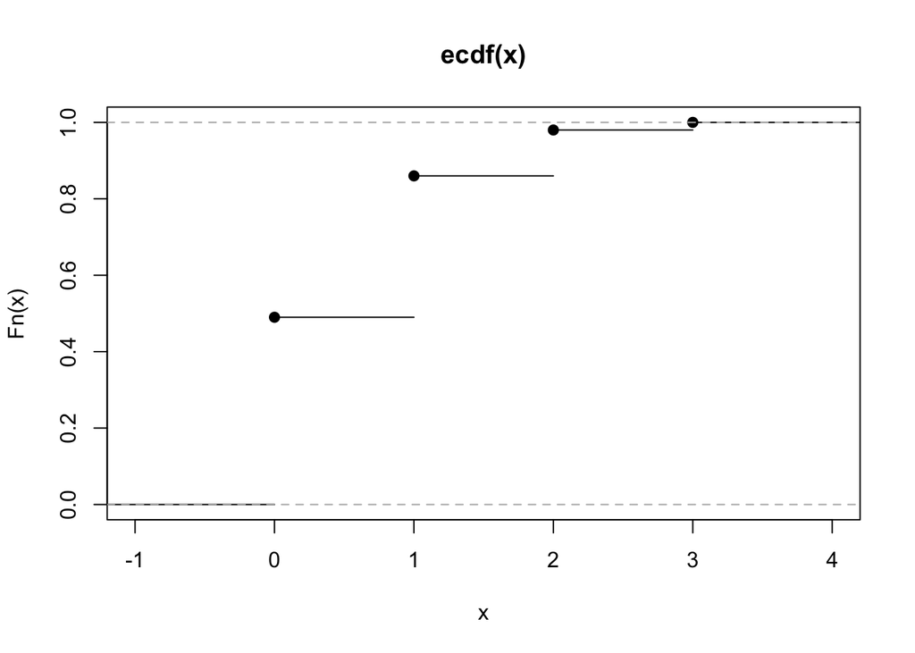

```r
plot(ecdf(x))
```

```r
# understand dbinom
dbinom(0:10, size=n*(n-1)/2, prob=p)
```

```
##  [1] 4.689767e-01 3.555977e-01 1.343261e-01 3.370453e-02 6.319599e-03
##  [6] 9.444675e-04 1.171935e-04 1.241847e-05 1.147173e-06 9.384688e-08
## [11] 6.883823e-09
```

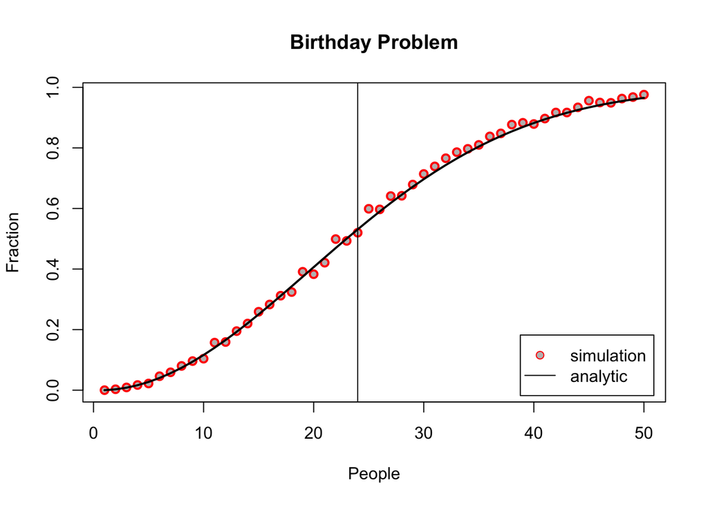

```r
n = 1:50
N = n*(n-1)/2
#N is a vector!!!
fa = 1 - dbinom(0,N,p)

plot(1:50, fract, main="Birthday Problem", xlab="People", ylab="Fraction", col="red", pch=21, bg="grey",lwd=2)
points(n, fa, type="l", lwd=2)
#?points
legend("bottomright",inset=0.02, legend=c("simulation", "analytic"),
       pch=c(21,NA), pt.bg=c("grey",NA), lty=c(NA,1), col=c("red","black"))
abline(v=24)
```

Again we see that, for $n>23$, we expect that $>50\%$ of parties have matching birthdays.

# Multiple Testing correction

Now, let’s consider statsitical testing. Statsitical tests are often phrased in terms of a null hypothesis and data is used to calculate a score (for which the distribution is known). Take again the binomial example. We may want to test the null hypothesis that a coin is fair ($p=0.5$) and we have $N=10$ observations that resulted in 9 heads.

```r
# null hypothesis: fair coin ==> binomial with p=0.5
p=0.5
# observed data (independent) H H L H H H .... => 10 throws, 9 heads
# statistic
N=10
S=9

# probability of observing 9 or more heads if coin is fair
# Notice that (S>=9) = (S>8)
pvalue=pbinom(S-1,N,p,lower.tail=FALSE)
pvalue
```

```
## [1] 0.01074219
```

```r
# try with S=8
# reject ?
```

In this case we would reject the null hypothesis of a fair coin. Now let’s test 10000 **fair coins**, each with 10 throws and a criterion (S>8) to reject the null hypothesis. How many rejections (false positives)?

```r
m=10000
x=rbinom(m,10,p)
fp=sum(x>8)
fp
```

```
## [1] 105
```

```r
table(x)
```

```
## x
##    0    1    2    3    4    5    6    7    8    9   10
##   11   90  451 1166 2040 2480 2062 1160  435   95   10
```

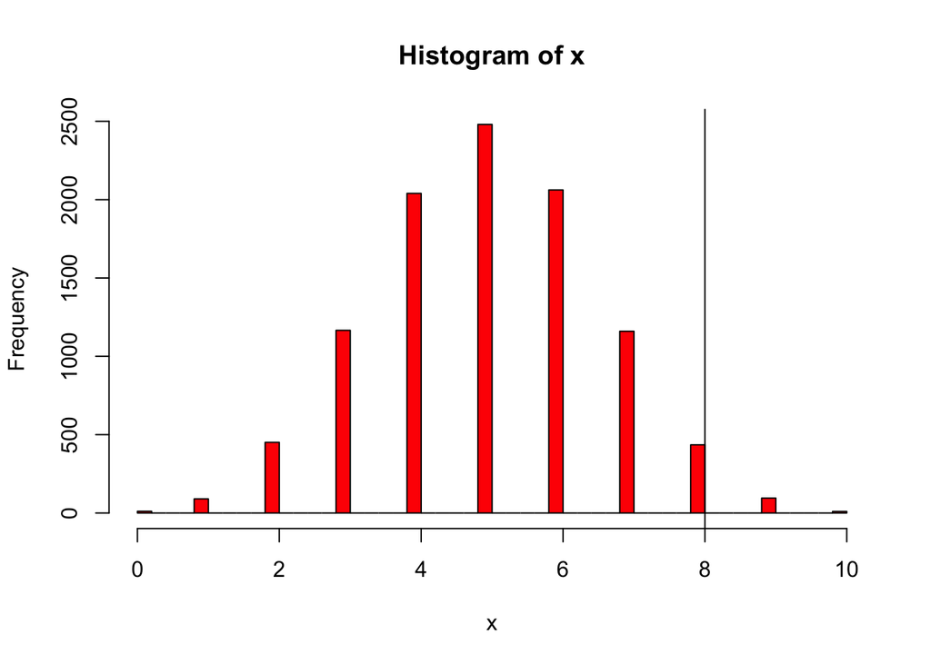

```r
# adjust breakpoints, histogram is for continuous distributions
hist(x,50,col="red")
abline(v=8)
```

Plot two distribution: one for number of successes, one for associated p-values

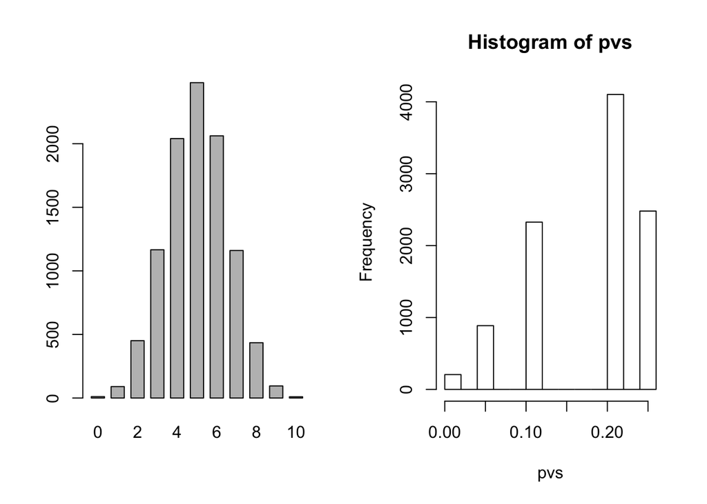

```r
pvs=dbinom(x,10,p)
par(mfcol=c(1,2))
barplot(table(x), space=0.5)
hist(pvs)
```

# Did you understand?

- sample with replacement
- queries on vectors: sum, sort, duplicated entires, any
- matrix from vector
- apply more efficient than loops
- plotting options, points, legend, abline
- analytical formalism more efficient than simulation
- hist, ecdf
- plot layout: par()
- binomial distribution and others: rbinom, dbinom, pbinom
- multiple testing correction